# Quick start for NPH sample size and power

Keaven M. Anderson

Please see https://merck.github.io/gsDesign2/articles/ for the full set of articles.  
This vignette is only a quick start guide.

# 1 Overview

We provide simple examples for use of the **gsDesign2** package for deriving fixed and group sequential designs under non-proportional hazards. The piecewise model for enrollment, failure rates, dropout rates and changing hazard ratio over time allow great flexibility in design assumptions. Users are encouraged to suggest features that would be of immediate and long-term interest to add.

Topics included here are:

- Packages required and how they are used.
- Specifying enrollment rates.
- Specifying failure and dropout rates with possibly changing hazard ratio over time.
- Deriving a fixed design with no interim analysis.
- Simple boundary specification for group sequential design.
- Deriving a group sequential design under non-proportional hazards.
- Displaying design properties.
- Design properties under alternate assumptions.
- Differences from **gsDesign**.
- Future enhancement priorities.

# 2 Packages used

- The **gsDesign** package is used as a check for results under proportional hazards as well as a source from deriving bounds using spending functions.
- The **gsDesign2** package provides
  - computations to compute expected event accumulation and average hazard ratio over time; these are key inputs to the group sequential distribution parameters.
  - implement group sequential distribution theory under non-proportional hazards and to derive a wide variety of boundary types for group sequential designs.
- The **simtrial** package is used to verify design properties using simulation.

```r
library(gsDesign)
library(gsDesign2)
library(knitr)
library(dplyr)
library(gt)
library(ggplot2)
```

# 3 Enrollment rates

Piecewise constant enrollment rates are input in a tabular format. Here we assume enrollment will ramp-up with $25\%$, $50\%$, and $75\%$ of the final enrollment rate for $2$ months each followed by a steady state $100\%$ enrollment for another $6$ months. The rates will be increased later to power the design appropriately. However, the fixed enrollment rate periods will remain unchanged.

```r
enroll_rate <- define_enroll_rate(
  duration = c(2, 2, 2, 6),
  rate = (1:4) / 4
)

enroll_rate %>% gt()
```

| stratum | duration | rate |
| --- | --- | --- |
| All | 2 | 0.25 |
| All | 2 | 0.50 |
| All | 2 | 0.75 |
| All | 6 | 1.00 |

# 4 Failure and dropout rates

Constant failure and dropout rates are specified by study period and stratum; we consider a single stratum here. A hazard ratio is provided for treatment/control hazard rate for each period and stratum. The dropout rate for each period is assumed the same for each treatment group; this restriction could be eliminated in a future version, if needed. Generally, we take advantage of the identity for an exponential distribution with median $m$, the corresponding failure rate $\lambda$ is

$$\lambda = \log(2) / m.$$

We consider a control group exponential time-to-event with a $12$ month median. We assume a hazard ratio of $1$ for $4$ months, followed by a hazard ratio of $0.6$ thereafter. Finally, we assume a low $0.001$ exponential dropout rate per month for both treatment groups.

```r
median_surv <- 12

fail_rate <- define_fail_rate(
  duration = c(4, Inf),
  fail_rate = log(2) / median_surv,
  hr = c(1, .6),
  dropout_rate = .001
)

fail_rate %>% gt()
```

| stratum | duration | fail_rate | dropout_rate | hr |
| --- | --- | --- | --- | --- |
| All | 4 | 0.05776227 | 0.001 | 1.0 |
| All | Inf | 0.05776227 | 0.001 | 0.6 |

# 5 Fixed design

Under the above enrollment, failure and dropout rate assumptions we now derive sample size for a trial targeted to complete in 36 months with no interim analysis, $90\%$ power and $2.5\%$ Type I error.

```r
alpha <- .025
beta <- .1 # 1 - targeted power
d <- fixed_design_ahr(
  enroll_rate = enroll_rate, # Relative enrollment rates
  fail_rate = fail_rate, # Failure rates from above
  alpha = alpha, # Type I error
  power = 1 - beta, # Type II error = 1 - power
  study_duration = 36 # Planned trial duration
)
```

A quick summary of the targeted sample size is obtained below. Note that you would normally round up `N` up to an even number and `Events` to the next integer.

```r
d %>%
  summary() %>%
  as_gt()
```

Fixed Design under AHR Method<sup>1</sup>

| Design | N | Events | Time | Bound | alpha | Power |
| --- | --- | --- | --- | --- | --- | --- |
| Average hazard ratio | 433.6922 | 315.2547 | 36 | 1.959964 | 0.025 | 0.9 |

<sup>1</sup> Power computed with average hazard ratio method.

The enrollment rates for each period have been increased proportionately to size the trial for the desired properties; the duration for each enrollment rate has not changed.

```r
d$enroll_rate %>% gt()
```

| stratum | duration | rate |
| --- | --- | --- |
| All | 2 | 12.04701 |
| All | 2 | 24.09401 |
| All | 2 | 36.14102 |
| All | 6 | 48.18802 |

# 6 Group sequential design

We will not go into detail for group sequential designs here. In brief, however, a sequence of tests $Z_1, Z_2,\ldots, Z_K$ that follow a multivariate normal distribution are performed to test if a new treatment is better than control (Jennison and Turnbull (1999)). We assume $Z_k > 0$ is favorable for the experimental treatment. Generally Type I error for this set of tests will be controlled under the null hypothesis of no treatment difference by a sequence of bounds $b_1, b_2,\ldots,b_K$ such that for a chosen Type I error $\alpha > 0$ we have

$$\alpha = 1 - P_0(\cap_{k=1}^K Z_k < b_k)$$
Where $P_0()$ refers to a probability under the null hypothesis. This is referred to as a non-binding bound since it is assumed the trial will not be stopped early for futility if some $Z_k$ is small.

## 6.1 Simple efficacy bound definition

Lan and DeMets (1983) developed the spending function method for deriving group sequential bounds. This involves use of a non-decreasing spending function $f(t)$ for $t \geq 0$ where $f(0)=0$ and $f(t)=\alpha$ for $t \geq 1$. Suppose for $K>0$ analyses are performed when proportion $t_1< t_2 <\ldots t_K=1$ of some planned statistical information (e.g., proportion of planned events for a time-to-event endpoint trial for proportion of observations for a binomial or normal endpoint). Bounds through the first $k$ analyses $1\leq k\leq K$ are recursively defined by the spending function and the multivariate normal distribution to satisfy

$$f(t_k) = 1 - P_0(\cap_{j=1}^k Z_j < b_j).$$
For this quick start, we will only illustrate this type of efficacy bound.

Perhaps the most common spending function for this approach is the Lan and DeMets (1983) approximation to the O’Brien-Fleming bound with

$$f(t) = 2-2\Phi\left(\frac{\Phi^{-1}(1-\alpha/2)}{t^{1/2}}\right).$$

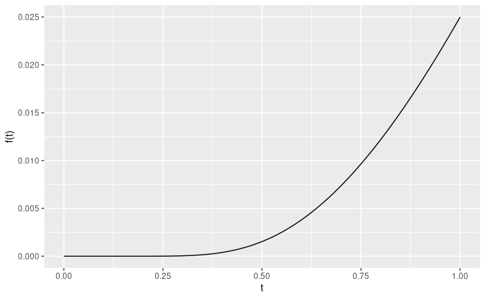

```r
design1s <- gs_design_ahr(
  alpha = alpha,
  beta = beta,
  enroll_rate = enroll_rate,
  fail_rate = fail_rate,
  analysis_time = c(16, 26, 36), # Calendar time of planned analyses
  upper = gs_spending_bound, # Spending function bound for efficacy
  upar = list(sf = gsDesign::sfLDOF, total_spend = 0.025), # Specify spending function and total Type I error
  lower = gs_b, lpar = rep(-Inf, 3), # No futility bound
  info_scale = "h0_h1_info"
)
```

Bounds at the 3 analyses are as follows. Note that expected sample size at time of each data cutoff for analysis is also here in `N`. We filter on the upper bound so that lower bounds with `Z = -Inf` are not shown.

```r
design1s %>%
  summary() %>%
  as_gt(
    title = "1-sided group sequential bound using AHR method",
    subtitle = "Lan-DeMets spending to approximate O'Brien-Fleming bound"
  )
```

1-sided group sequential bound using AHR method

Lan-DeMets spending to approximate O'Brien-Fleming bound

| Bound | Z | Nominal p<sup>1</sup> | ~HR at bound<sup>2</sup> | Cumulative boundary crossing probability Alternate hypothesis | Cumulative boundary crossing probability Null hypothesis |
| --- | --- | --- | --- | --- | --- |
| Analysis: 1 Time: 16 N: 449 Events: 159.3 AHR: 0.81 Information fraction: 0.49 |  |  |  |  |  |
| Efficacy | 3.00 | 0.0013 | 0.6213 | 0.0511 | 0.0013 |
| Analysis: 2 Time: 26 N: 449 Events: 262.6 AHR: 0.72 Information fraction: 0.8 |  |  |  |  |  |
| Efficacy | 2.26 | 0.0120 | 0.7570 | 0.6580 | 0.0125 |
| Analysis: 3 Time: 36 N: 449 Events: 326.4 AHR: 0.69 Information fraction: 1 |  |  |  |  |  |
| Efficacy | 2.03 | 0.0212 | 0.7988 | 0.9000 | 0.0250 |

<sup>1</sup> One-sided p-value for experimental vs control treatment. Value < 0.5 favors experimental, > 0.5 favors control.  
<sup>2</sup> Approximate hazard ratio to cross bound.

gsDesign to replicate above bounds (this will not replicate sample size).

```r
x <- gsDesign(k = 3, test.type = 1, timing = design1s$analysis$info_frac, sfu = sfLDOF)
cat(
  "gsDesign\n  Upper bound: ", x$upper$bound,
  "\n  Cumulative boundary crossing probability (H0): ", cumsum(x$upper$prob[, 1]),
  "\n  Timing (IF): ", x$timing,
  "\ngs_design_ahr\n  Upper bound: ", design1s$bound$z,
  "\n  Cumulative boundary crossing probability (H0): ", design1s$bound$probability0,
  "\n  Timinng (IF): ", design1s$analysis$info_frac,
  "\n"
)
```

```
#> gsDesign
#>   Upper bound:  3.013804 2.264946 2.027236
#>   Cumulative boundary crossing probability (H0):  0.00128997 0.01217731 0.025
#>   Timing (IF):  0.4850799 0.7993622 1
#> gs_design_ahr
#>   Upper bound:  3.003506 2.256138 2.028823
#>   Cumulative boundary crossing probability (H0):  0.001334442 0.01246455 0.025
#>   Timinng (IF):  0.4850799 0.7993622 1
```

## 6.2 Two-sided testing

We will consider both symmetric and asymmetric 2-sided designs.

### 6.2.1 Symmetric 2-sided bounds

Our first 2-sided design is a symmetric design.

```r
design2ss <- gs_design_ahr(
  alpha = alpha,
  beta = beta,
  enroll_rate = enroll_rate,
  fail_rate = fail_rate,
  analysis_time = c(16, 26, 36), #  Calendar analysis times
  upper = gs_spending_bound,
  upar = list(sf = gsDesign::sfLDOF, total_spend = 0.025),
  lower = gs_spending_bound,
  lpar = list(sf = gsDesign::sfLDOF, total_spend = 0.025),
  h1_spending = FALSE # This specifies futility testing with spending under NULL
)
```

Design bounds are confirmed with:

```r
design2ss %>%
  summary() %>%
  as_gt(
    title = "2-sided symmetric group sequential bound using AHR method",
    subtitle = "Lan-DeMets spending to approximate O'Brien-Fleming bound"
  )
```

2-sided symmetric group sequential bound using AHR method

Lan-DeMets spending to approximate O'Brien-Fleming bound

| Bound | Z | Nominal p<sup>1</sup> | ~HR at bound<sup>2</sup> | Cumulative boundary crossing probability Alternate hypothesis | Cumulative boundary crossing probability Null hypothesis |
| --- | --- | --- | --- | --- | --- |
| Analysis: 1 Time: 16 N: 449 Events: 159.3 AHR: 0.81 Information fraction: 0.49 |  |  |  |  |  |
| Futility | -3.00 | 0.9987 | 1.6096 | 0.0000 | 0.0013 |
| Efficacy | 3.00 | 0.0013 | 0.6213 | 0.0511 | 0.0013 |
| Analysis: 2 Time: 26 N: 449 Events: 262.6 AHR: 0.72 Information fraction: 0.8 |  |  |  |  |  |
| Futility | -2.26 | 0.9880 | 1.3211 | 0.0000 | 0.0125 |
| Efficacy | 2.26 | 0.0120 | 0.7570 | 0.6580 | 0.0125 |
| Analysis: 3 Time: 36 N: 449 Events: 326.4 AHR: 0.69 Information fraction: 1 |  |  |  |  |  |
| Futility | -2.03 | 0.9788 | 1.2518 | 0.0000 | 0.0250 |
| Efficacy | 2.03 | 0.0212 | 0.7988 | 0.9000 | 0.0250 |

<sup>1</sup> One-sided p-value for experimental vs control treatment. Value < 0.5 favors experimental, > 0.5 favors control.  
<sup>2</sup> Approximate hazard ratio to cross bound.

The bounds can be plotted easily:

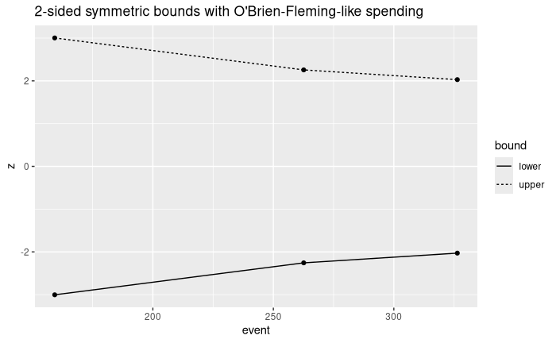

```r
ggplot(
  data = design2ss$analysis %>% left_join(design2ss$bound, by = "analysis"),
  aes(x = event, y = z, group = bound)
) +
  geom_line(aes(linetype = bound)) +
  geom_point() +
  ggtitle("2-sided symmetric bounds with O'Brien-Fleming-like spending")
```

### 6.2.2 Asymmetric 2-sided bounds

```r
design2sa <- gs_design_ahr(
  alpha = alpha,
  beta = beta,
  enroll_rate = enroll_rate,
  fail_rate = fail_rate,
  analysis_time = c(12, 16, 26, 36),
  upper = gs_spending_bound,
  upar = list(sf = gsDesign::sfLDOF, total_spend = 0.025), # Same efficacy bound as before
  test_lower = c(FALSE, TRUE, TRUE, TRUE), # Only test efficacy after IA1
  lower = gs_b,
  lpar = c(rep(qnorm(.05), 2), -Inf, -Inf) # Fixed lower bound at first 2 analyses
)
```

We now have a slightly larger sample size to account for the possibility of an early futility stop. Bounds are now:

```r
design2sa %>%
  summary() %>%
  as_gt(
    title = "2-sided asymmetric group sequential bound using AHR method",
    subtitle = "Lan-DeMets spending to approximate O'Brien-Fleming bound
    for efficacy, futility disaster check at IA1, IA2 only"
  )
```

2-sided asymmetric group sequential bound using AHR method

Lan-DeMets spending to approximate O'Brien-Fleming bound for efficacy, futility disaster check at IA1, IA2 only

[output not shown]

<sup>1</sup> One-sided p-value for experimental vs control treatment. Value < 0.5 favors experimental, > 0.5 favors control.  
<sup>2</sup> Approximate hazard ratio to cross bound.

# References

Jennison, Christopher, and Bruce W Turnbull. 1999. *Group Sequential Methods with Applications to Clinical Trials*. Chapman & Hall/CRC.

Lan, K. K. Gordon, and David L DeMets. 1983. “Discrete Sequential Boundaries for Clinical Trials.” *Biometrika* 70 (3): 659–63.